# Homework #4

Ximu Wang

2019/2/16

```r
library(e1071)
library(mlbench)
library(randomForest)
library(tree)
library(dplyr)
```

```r
library(ggplot2)
library(glmnet)
library(pROC)
library(rsample)
library(car)
library(MASS)
library(class)
library(rpart)
library(ROCR)
library(caret)
```

#### Read and summary the data.

```r
telco <- read.csv("Telco-Customer-Churn.csv")
head(telco)
```

```
##   customerID gender SeniorCitizen Partner Dependents tenure PhoneService
## 1 7590-VHVEG Female             0     Yes         No      1           No
## 2 5575-GNVDE   Male             0      No         No     34          Yes
## 3 3668-QPYBK   Male             0      No         No      2          Yes
## 4 7795-CFOCW   Male             0      No         No     45           No
## 5 9237-HQITU Female             0      No         No      2          Yes
## 6 9305-CDSKC Female             0      No         No      8          Yes
##      MultipleLines InternetService OnlineSecurity OnlineBackup
## 1 No phone service             DSL             No          Yes
## 2               No             DSL            Yes           No
## 3               No             DSL            Yes          Yes
## 4 No phone service             DSL            Yes           No
## 5               No     Fiber optic             No           No
## 6              Yes     Fiber optic             No           No
##   DeviceProtection TechSupport StreamingTV StreamingMovies       Contract
```

[output cut: 20 more lines]

```r
summary(telco)
```

```
##       customerID      gender     SeniorCitizen    Partner    Dependents
##  0002-ORFBO:   1   Female:3488   Min.   :0.0000   No :3641   No :4933
##  0003-MKNFE:   1   Male  :3555   1st Qu.:0.0000   Yes:3402   Yes:2110
##  0004-TLHLJ:   1                 Median :0.0000
##  0011-IGKFF:   1                 Mean   :0.1621
##  0013-EXCHZ:   1                 3rd Qu.:0.0000
##  0013-MHZWF:   1                 Max.   :1.0000
##  (Other)   :7037
##      tenure      PhoneService          MultipleLines     InternetService
##  Min.   : 0.00   No : 682     No              :3390   DSL        :2421
##  1st Qu.: 9.00   Yes:6361     No phone service: 682   Fiber optic:3096
##  Median :29.00                Yes             :2971   No         :1526
##  Mean   :32.37
##  3rd Qu.:55.00
##  Max.   :72.00
##
##              OnlineSecurity              OnlineBackup
##  No                 :3498   No                 :3088
##  No internet service:1526   No internet service:1526
##  Yes                :2019   Yes                :2429
##
##
##
##
##             DeviceProtection              TechSupport
##  No                 :3095    No                 :3473
##  No internet service:1526    No internet service:1526
##  Yes                :2422    Yes                :2044
##
##
##
##
##               StreamingTV              StreamingMovies
##  No                 :2810   No                 :2785
##  No internet service:1526   No internet service:1526
##  Yes                :2707   Yes                :2732
##
##
##
##
##            Contract    PaperlessBilling                   PaymentMethod
##  Month-to-month:3875   No :2872         Bank transfer (automatic):1544
##  One year      :1473   Yes:4171         Credit card (automatic)  :1522
##  Two year      :1695                    Electronic check         :2365
##                                         Mailed check             :1612
##
##
##
##  MonthlyCharges    TotalCharges    Churn
##  Min.   : 18.25   Min.   :  18.8   No :5174
##  1st Qu.: 35.50   1st Qu.: 401.4   Yes:1869
##  Median : 70.35   Median :1397.5
##  Mean   : 64.76   Mean   :2283.3
##  3rd Qu.: 89.85   3rd Qu.:3794.7
##  Max.   :118.75   Max.   :8684.8
##                   NA's   :11
```

#### Clean the data.

```r
sum(is.na(telco$customerID))
```

```
## [1] 0
```

```r
sum(is.na(telco$gender))
```

```
## [1] 0
```

```r
sum(is.na(telco$SeniorCitizen))
```

```
## [1] 0
```

```r
sum(is.na(telco$Partner))
```

```
## [1] 0
```

```r
sum(is.na(telco$Dependents))
```

```
## [1] 0
```

```r
sum(is.na(telco$tenure))
```

```
## [1] 0
```

```r
sum(is.na(telco$PhoneService))
```

```
## [1] 0
```

```r
sum(is.na(telco$MultipleLines))
```

```
## [1] 0
```

```r
sum(is.na(telco$InternetService))
```

```
## [1] 0
```

```r
sum(is.na(telco$OnlineSecurity))
```

```
## [1] 0
```

```r
sum(is.na(telco$OnlineBackup))
```

```
## [1] 0
```

```r
sum(is.na(telco$DeviceProtection))
```

```
## [1] 0
```

```r
sum(is.na(telco$TechSupport))
```

```
## [1] 0
```

```r
sum(is.na(telco$StreamingTV))
```

```
## [1] 0
```

```r
sum(is.na(telco$StreamingMovies))
```

```
## [1] 0
```

```r
sum(is.na(telco$Contract))
```

```
## [1] 0
```

```r
sum(is.na(telco$PaperlessBilling))
```

```
## [1] 0
```

```r
sum(is.na(telco$PaymentMethod))
```

```
## [1] 0
```

```r
sum(is.na(telco$MonthlyCharges))
```

```
## [1] 0
```

```r
sum(is.na(telco$TotalCharges))
```

```
## [1] 11
```

```r
sum(is.na(telco$Churn))
```

```
## [1] 0
```

We can see there is some missing data in category “TotalCharges”, so we delete the rows that have missing data. And we don’t need “customerID” to predict.

```r
telco <- na.omit(telco)
sum(is.na(telco$TotalCharges))
```

```
## [1] 0
```

```r
telco <- telco[-1]
```

#### Recode the values.

```r
telco[, c("gender", "Partner", "Dependents", "PhoneService", "MultipleLines", "InternetService", "OnlineSecurity", "OnlineBackup", "DeviceProtection", "TechSupport", "StreamingTV", "StreamingMovies", "Contract", "PaperlessBilling", "PaymentMethod")] <- lapply(telco[, c("gender", "Partner", "Dependents", "PhoneService", "MultipleLines", "InternetService", "OnlineSecurity", "OnlineBackup", "DeviceProtection", "TechSupport", "StreamingTV", "StreamingMovies", "Contract", "PaperlessBilling", "PaymentMethod")], as.numeric)

telco$Churn <- recode(telco$Churn, " 'Yes'=1;else=0")
telco$Churn <- as.numeric(levels(telco$Churn)[telco$Churn])
table(telco$Churn)
```

```
##
##    0    1
## 5163 1869
```

## Question #1

#### Split train set and test set.

```r
set.seed(50)

telco_train_test_split <- initial_split(telco, prop = 0.7)
telco_train_tbl <- training(telco_train_test_split)
telco_test_tbl <- testing(telco_train_test_split)
```

#### Build random forests model. Show the importance of each variables and list them from most important to least.

```r
telco_treef <- randomForest(formula = Churn ~ ., data = telco, importance = TRUE, ntree = 50)
```

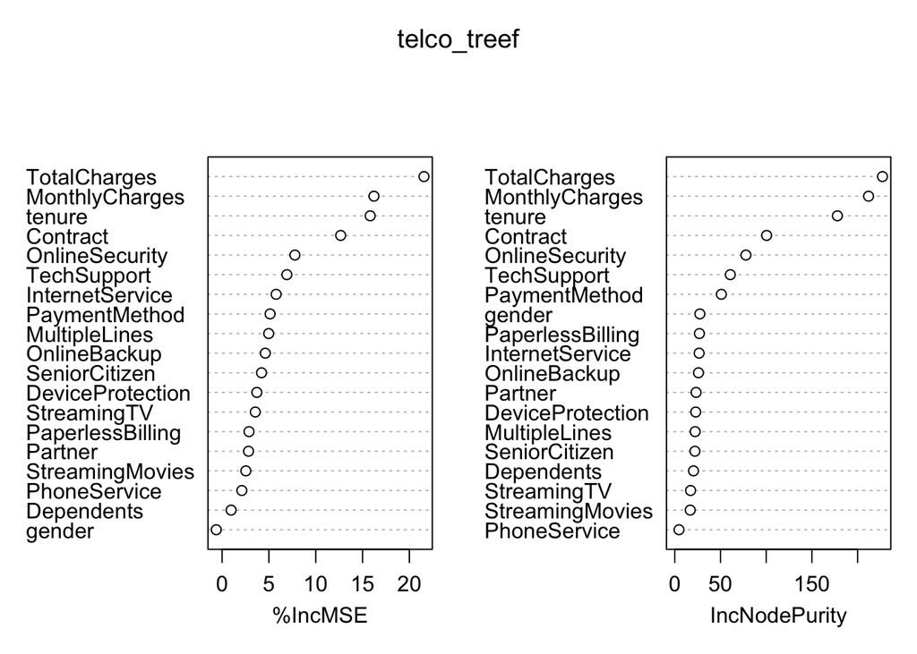

```r
varImpPlot(telco_treef)
```

#### Run cv with random forests model to select feature.

```r
telco_treef_cv <- rfcv(telco[, c(1:19)], telco$Churn, cv.fold = 5, step = .5)
```

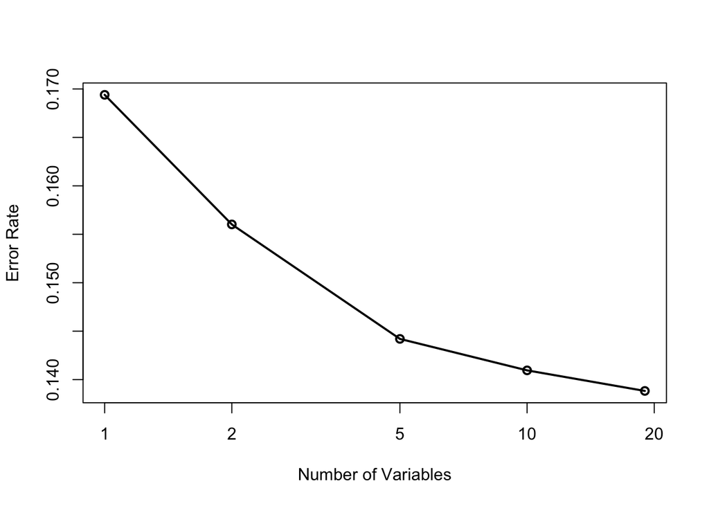

```r
with(telco_treef_cv, plot(n.var, error.cv, log="x", type="o", lwd=2,
                    xlab="Number of Variables", ylab="Error Rate"))
```

```r
telco_treef_cv$error.cv
```

```
##        19        10         5         2         1
## 0.1388333 0.1409562 0.1442041 0.1560195 0.1693934
```

We can see the more variables, the error rate of the model will be less. So the 19 predictors are all optimal for this dataset.

## Question #2

### Logistic Regression

```r
telco_lr <- glm(Churn~., family = binomial, data = telco)
summary(telco_lr)
```

```
##
## Call:
## glm(formula = Churn ~ ., family = binomial, data = telco)
##
## Deviance Residuals:
##     Min       1Q   Median       3Q      Max
## -1.8936  -0.6860  -0.2888   0.7413   3.4151
##
## Coefficients:
##                    Estimate Std. Error z value Pr(>|z|)
## (Intercept)       1.460e+00  3.700e-01   3.946 7.93e-05 ***
## gender           -2.707e-02  6.458e-02  -0.419 0.675053
## SeniorCitizen     2.390e-01  8.414e-02   2.840 0.004509 **
## Partner           1.660e-02  7.745e-02   0.214 0.830296
## Dependents       -1.639e-01  8.939e-02  -1.834 0.066661 .
## tenure           -5.920e-02  6.198e-03  -9.551  < 2e-16 ***
## PhoneService     -1.034e+00  1.457e-01  -7.100 1.25e-12 ***
## MultipleLines     7.227e-02  4.061e-02   1.779 0.075173 .
## InternetService   2.360e-01  6.519e-02   3.621 0.000294 ***
## OnlineSecurity   -2.707e-01  4.140e-02  -6.538 6.24e-11 ***
## OnlineBackup     -1.440e-01  3.810e-02  -3.779 0.000158 ***
## DeviceProtection -8.811e-02  3.926e-02  -2.245 0.024794 *
## TechSupport      -2.629e-01  4.193e-02  -6.270 3.60e-10 ***
## StreamingTV      -3.918e-03  4.116e-02  -0.095 0.924164
## StreamingMovies  -7.841e-04  4.106e-02  -0.019 0.984765
## Contract         -7.018e-01  7.718e-02  -9.093  < 2e-16 ***
## PaperlessBilling  3.674e-01  7.408e-02   4.959 7.07e-07 ***
## PaymentMethod     4.781e-02  3.536e-02   1.352 0.176314
## MonthlyCharges    2.288e-02  2.222e-03  10.301  < 2e-16 ***
## TotalCharges      3.077e-04  7.029e-05   4.378 1.20e-05 ***
## ---
## Signif. codes:  0 '***' 0.001 '**' 0.01 '*' 0.05 '.' 0.1 ' ' 1
##
## (Dispersion parameter for binomial family taken to be 1)
##
##     Null deviance: 8143.4  on 7031  degrees of freedom
## Residual deviance: 5854.5  on 7012  degrees of freedom
## AIC: 5894.5
##
## Number of Fisher Scoring iterations: 6
```

We can see “SeniorCitizen”, “tenure”, “PhoneService”, “InternetService”, “OnlineSecurity”, “OnlineProtection”, “OnlineBackup”, “TechSupport”, “Contract”, “PaperlessBilling”, “MonthlyCharges” and “TotalCharges” are significient features, so we use them to do feature selection. #### Use LASSO to select features.

```r
lr_train_vars <- telco_train_tbl[, c(2, 5, 6, 8, 9, 10, 11, 12, 15, 16, 18, 19)]
lr_test_vars <- telco_test_tbl[, c(2, 5, 6, 8, 9, 10, 11, 12, 15, 16, 18, 19)]

lr_lasso <- cv.glmnet(x = as.matrix(lr_train_vars), y = telco_train_tbl$Churn, alpha = 1, family = "binomial")
coef(lr_lasso, s = "lambda.min")
```

```
## 13 x 1 sparse Matrix of class "dgCMatrix"
##                             1
## (Intercept)       1.382997053
## SeniorCitizen     0.173413416
## tenure           -0.052151520
## PhoneService     -1.057126932
## InternetService   0.240813863
## OnlineSecurity   -0.327966597
## OnlineBackup     -0.140076014
## DeviceProtection -0.067876316
## TechSupport      -0.220106447
## Contract         -0.725560002
## PaperlessBilling  0.391704223
## MonthlyCharges    0.024672381
## TotalCharges      0.000235052
```

We can see the coefficient of “TotalCharges” are too small, so we discard it. #### Final logistic regression model.

```r
lr_train_vars <- telco_train_tbl[, c(2, 5, 6, 8, 9, 10, 11, 12, 15, 16, 18)]
lr_test_vars <- telco_test_tbl[, c(2, 5, 6, 8, 9, 10, 11, 12, 15, 16, 18)]

telco_lr <- glm(Churn ~ ., family = binomial, data = telco_train_tbl[, c(2, 5, 6, 8, 9, 10, 11, 12, 15, 16, 18, 20)])
```

#### Creat ROC and calculate AUC.

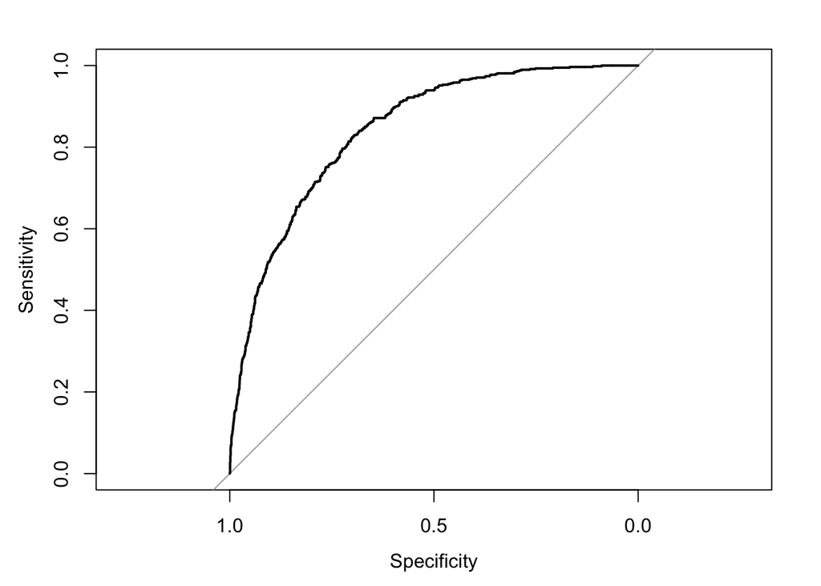

```r
lr_predict <- predict(telco_lr, newdata = lr_test_vars, type = "response")
lr_roc <- roc(telco_test_tbl$Churn, lr_predict)
lr_auc <- auc(lr_roc)
plot(lr_roc)
```

```r
lr_auc
```

```
## Area under the curve: 0.8418
```

The auc is 0.8418

#### The confidence of logistic regression model.

```r
ci.auc(lr_auc)
```

```
## 95% CI: 0.8241-0.8595 (DeLong)
```

### kNN model

```r
telco_knn <- knn(train = lr_train_vars, test = lr_test_vars, cl = telco_train_tbl$Churn, k = 3, prob = TRUE)
telco_knn
```

[output not shown]

[output cut: 402 more lines]

#### Creat ROC and calculate AUC.

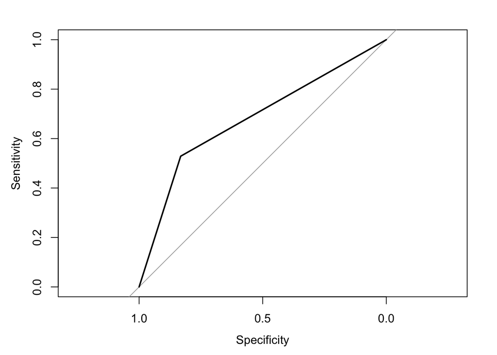

```r
knn_roc <- roc(telco_test_tbl$Churn, as.numeric(telco_knn))
knn_auc <- auc(knn_roc)
plot(knn_roc)
```

```r
knn_auc
```

```
## Area under the curve: 0.6803
```

The auc is 0.6803

#### The confidence of kNN model

```r
ci.auc(knn_auc)
```

```
## 95% CI: 0.6578-0.7027 (DeLong)
```

### SVM model

```r
telco_train_tbl$SeniorCitizen <- as.factor(telco_train_tbl$SeniorCitizen)
telco_train_tbl$PhoneService <- as.factor(telco_train_tbl$PhoneService)
telco_train_tbl$InternetService <- as.factor(telco_train_tbl$InternetService)
telco_train_tbl$OnlineSecurity <- as.factor(telco_train_tbl$OnlineSecurity)
telco_train_tbl$OnlineBackup <- as.factor(telco_train_tbl$OnlineBackup)
telco_train_tbl$DeviceProtection <- as.factor(telco_train_tbl$DeviceProtection)
telco_train_tbl$TechSupport <- as.factor(telco_train_tbl$TechSupport)
telco_train_tbl$Contract <- as.factor(telco_train_tbl$Contract)
telco_train_tbl$PaperlessBilling <- as.factor(telco_train_tbl$PaperlessBilling)
telco_train_tbl$Churn <- as.factor(telco_train_tbl$Churn)

telco_svm <- svm(Churn ~ ., probability = TRUE, data = telco_train_tbl[, c(2, 5, 6, 8, 9, 10, 11, 12, 15, 16, 18, 20)])
summary(telco_svm)
```

```
##
## Call:
## svm(formula = Churn ~ ., data = telco_train_tbl[, c(2, 5, 6,
##     8, 9, 10, 11, 12, 15, 16, 18, 20)], probability = TRUE)
##
##
## Parameters:
##    SVM-Type:  C-classification
##  SVM-Kernel:  radial
##        cost:  1
##       gamma:  0.05555556
##
## Number of Support Vectors:  2205
##
##  ( 1114 1091 )
##
##
## Number of Classes:  2
##
## Levels:
##  0 1
```

#### Create ROC and calculate AUC.

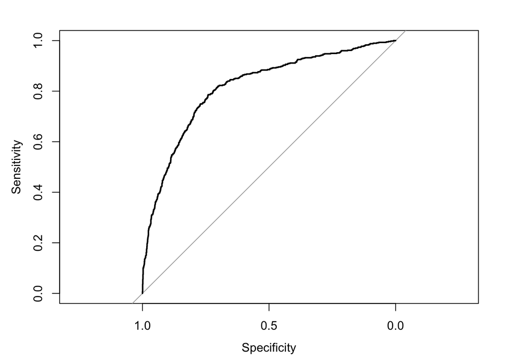

```r
lr_test_vars$SeniorCitizen <- as.factor(lr_test_vars$SeniorCitizen)
lr_test_vars$PhoneService <- as.factor(lr_test_vars$PhoneService)
lr_test_vars$InternetService <- as.factor(lr_test_vars$InternetService)
lr_test_vars$OnlineSecurity <- as.factor(lr_test_vars$OnlineSecurity)
lr_test_vars$OnlineBackup <- as.factor(lr_test_vars$OnlineBackup)
lr_test_vars$DeviceProtection <- as.factor(lr_test_vars$DeviceProtection)
lr_test_vars$TechSupport <- as.factor(lr_test_vars$TechSupport)
lr_test_vars$Contract <- as.factor(lr_test_vars$Contract)
lr_test_vars$PaperlessBilling <- as.factor(lr_test_vars$PaperlessBilling)
telco_test_tbl$Churn <- as.factor(telco_test_tbl$Churn)

svm_predict <- predict(telco_svm, lr_test_vars, probability = TRUE)
svm_probs <- data.frame(attr(svm_predict, "probabilities"))

svm_roc <- roc(telco_test_tbl$Churn, svm_probs$X1)
svm_auc <- auc(svm_roc)
plot(svm_roc)
```

```r
svm_auc
```

```
## Area under the curve: 0.8157
```

The auc is 0.8157

#### The confidence of svm model

```r
ci.auc(svm_auc)
```

```
## 95% CI: 0.7946-0.8367 (DeLong)
```

So, acording to auc, the logistic regression model performed best. I pretty confident in this model, because the 95% CI is between 0.8241 and 0.8595.

### Confusion Matrix

#### Select threshold

```r
test_target_tbl <- as.data.frame(telco_test_tbl$Churn)
test_target_tbl$predict <- lr_predict

thresholds <- data.frame(ci.thresholds(roc(test_target_tbl$`telco_test_tbl$Churn`, test_target_tbl$predict)))
print(thresholds)
```

```
##                    specificity.2.5. specificity.50. specificity.97.5.
## 0.0104746287243866       0.07496741       0.0893090         0.1029987
## 0.0125444219949586       0.09582790       0.1108214         0.1264668
## 0.0180008518196531       0.14928292       0.1668840         0.1857888
## 0.0245458286380225       0.18839635       0.2086050         0.2288136
## 0.0323075954891906       0.23011734       0.2516297         0.2731421
## 0.0351655736663465       0.24380704       0.2653194         0.2874837
## 0.0386164921214801       0.26401565       0.2861799         0.3083442
## 0.0392799487758535       0.26923077       0.2920469         0.3142112
## 0.0402855272209957       0.27509778       0.2979140         0.3207301
## 0.041158776120284        0.28096480       0.3037810         0.3259615
## 0.0529455373224212       0.32073012       0.3455020         0.3696219
## 0.054332441496223        0.32464146       0.3494133         0.3735332
## 0.0576761201369746       0.33767927       0.3617992         0.3865711
## 0.0577612333259214       0.33898305       0.3631030         0.3872229
## 0.0631436900404241       0.34874511       0.3741851         0.3970013
## 0.0636718139436352       0.35071708       0.3767927         0.4002608
## 0.0705029479842323       0.37027379       0.3963494         0.4211213
## 0.0751113496583861       0.38070404       0.4067797         0.4315515
## 0.078637605751645        0.38787484       0.4132986         0.4380704
## 0.0861914142303086       0.40547588       0.4322034         0.4563233
## 0.087817364509253        0.41069100       0.4361147         0.4608866
## 0.0884195378024442       0.41197849       0.4374185         0.4621904
## 0.0948938510861302       0.42698827       0.4537158         0.4784876
## 0.0995769323941321       0.43350717       0.4602347         0.4843546
## 0.100707986851891        0.43807040       0.4654498         0.4902216
## 0.107555444972723        0.45306389       0.4784876         0.5032595
## 0.112553670427761        0.46284224       0.4876141         0.5124022
## 0.113848468332729        0.46414602       0.4889179         0.5143416
## 0.114530231886056        0.46544980       0.4902216         0.5149935
## 0.12107211971977         0.47131682       0.4960887         0.5208605
## 0.122662387296203        0.47327249       0.4980443         0.5228325
## 0.123096932100945        0.47455997       0.4993481         0.5241199
## 0.132364387638792        0.49413299       0.5189048         0.5443286
## 0.135596994335805        0.49608866       0.5215124         0.5469361
## 0.136662506159636        0.49608866       0.5218383         0.5469524
## 0.140281956235444        0.50065189       0.5260756         0.5521512
## 0.141352013475372        0.50130378       0.5267275         0.5521512
## 0.147287490927053        0.51238592       0.5371578         0.5625815
## 0.153983778264464        0.52346806       0.5482399         0.5736799
```

[output cut: 547 more lines]

```
## 0.724403145649118        0.10434783      0.13217391       0.160000000
## 0.728822780440239        0.10086957      0.12695652       0.153086957
## 0.731843854876785        0.09565217      0.12173913       0.147826087
## 0.734099838525206        0.09217391      0.11652174       0.142608696
## 0.737835442684166        0.08347826      0.10782609       0.132173913
## 0.73924018970101         0.08000000      0.10434783       0.128695652
## 0.742999503950738        0.07478261      0.09739130       0.121739130
## 0.744626592235085        0.07304348      0.09565217       0.120000000
## 0.746338383284275        0.06956522      0.09217391       0.116521739
## 0.747235762846362        0.06434783      0.08695652       0.109565217
## 0.756464784664346        0.05043478      0.06956522       0.092173913
## 0.75988782159674         0.04521739      0.06434783       0.085217391
## 0.775003822577053        0.02782609      0.04347826       0.060869565
## 0.78935167905248         0.01565217      0.02782609       0.041739130
## 0.829757266049554        0.00000000      0.00173913       0.005217391
```

We can see when the threshold equals to 0.3, our model perform good at both specificity and sensitivity. So we choose 0.3 as threshold. #### Create confusion matrix

```r
test_target <- test_target_tbl$`telco_test_tbl$Churn`
test_target_tbl <- mutate(test_target_tbl, decide = ifelse(predict >= 0.3, 1, 0))
predicted_churn <- test_target_tbl$decide
table(predicted_churn, test_target)
```

```
##                test_target
## predicted_churn    0    1
##               0 1132  134
##               1  402  441
```

Accuracy:

```r
Accuracy <- (1132 + 441)/(1132 + 134 + 402 + 441)
Accuracy
```

```
## [1] 0.7458511
```

Precision:

```r
Precision1 <- 1132 / (1132 + 134)
Precision1
```

```
## [1] 0.8941548
```

Negative Predictive Value:

```r
NPV <- 441 / (402 + 441)
NPV
```

```
## [1] 0.5231317
```

Recall:

```r
Recall <- 1132 / (1132 + 402)
Recall
```

```
## [1] 0.73794
```

Specificity:

```r
Specificity <- 441 / (134 + 441)
Specificity
```

```
## [1] 0.7669565
```

F-1 Score:

```r
F_1 <- 2 * Precision1 * Recall / (Precision1 + Recall)
F_1
```

```
## [1] 0.8085714
```

In the model, we have high confidence that the predicted Churn “No” is true “No”, but we are not very sure about the predicted predicted Churn “Yes” is true “Yes”.

## Bonus Question

#### Create lift curve

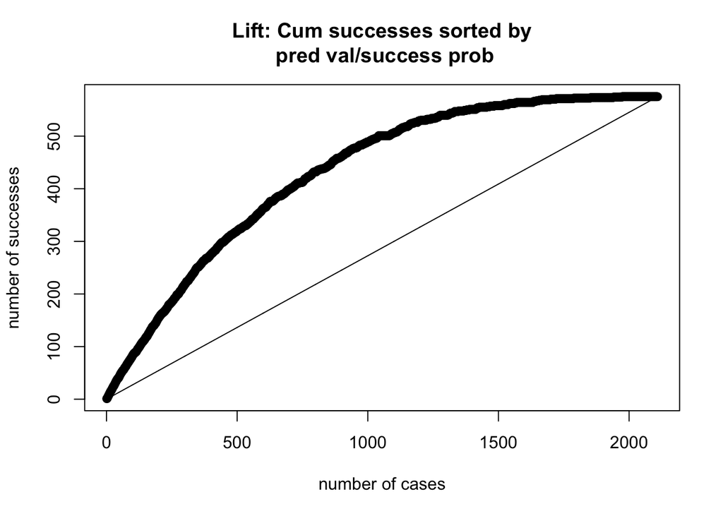

```r
telco_test_tbl$Churn <- as.numeric(telco_test_tbl$Churn)-1
lift_tbl <- data.frame(predict = lr_predict, target = telco_test_tbl$Churn)
lift_tbl <- lift_tbl %>% arrange(desc(predict))

baserate <- mean(lift_tbl$target)
n_test <- length(lift_tbl$target)
ax <- 1
ay_base <- baserate
ay_pred <- lift_tbl$target[1]

for (i in 2:n_test) {
  ax[i] = i
  ay_base[i] = baserate * i
  ay_pred[i] = ay_pred[i-1] + lift_tbl$target[i]
}

df=cbind(lift_tbl,ay_pred,ay_base)
plot(ax,ay_pred,xlab="number of cases",ylab="number of successes",
     main="Lift: Cum successes sorted by\n pred val/success prob")
points(ax,ay_base,type="l")
```

#### Suggestion

This model has a good perform at predict the Churn is “No”, so I think this model can help the company to improve thier advantage, but not to remedy their disadvantage.